# Evaluating 40 Years of Wetland Conservation Policy (1981–2025)

A Spatio-Temporal EDA of India’s RAMSAR Sites

Author

Shashank Venkatesh

Published

December 19, 2025

## Data Source

The foundational data for this analysis is sourced from the **Open Government Data (OGD) Platform India** catalog on **Ramsar Sites Details**. This dataset provides the geometric coordinates, area in hectares, and designation dates for the wetlands, allowing for a precise spatial and temporal analysis.

## Glimpse of the dataframe

```
Rows: 96
Columns: 13
$ WetlandID           <chr> "14634", "2108", "1296", "1284", "2079", "1302", "…
$ WetlandName         <chr> "Ankasamudra Bird Conservation Reserve", "Ansupa L…
$ Area                <chr> "9876.00", "231.00", "444.00", "6140.00", "2894.00…
$ DesignationDate     <chr> "2023-03-10", "2021-10-12", "2020-07-21", "2002-08…
$ Latitude            <chr> "15.12777", "20.460000", "30.43582649", "8.95", "2…
$ Longitude           <chr> "76.23361", "85.603056", "77.66555706", "76.583333…
$ ManagementAuthority <chr> "Retired Academic - University of Agricultural Sci…
$ MajorPlants         <chr> "", "Water Hyacinths", "", "", "Eichhornia crassip…
$ StateName           <chr> "Karnataka", "Odisha", "Uttarakhand", "Kerala", "U…
$ districtname        <chr> "Uttara Kannada", "Cuttack", "Dehradun", "Kollam",…
$ ramsar_sight        <chr> "1", "1", "1", "1", "1", "1", "1", "1", "1", "1", …
$ Uniqueness          <chr> "", "Ansupa Lake serves as a shelter for migratory…
$ WetlandType         <lgl> NA, NA, NA, NA, NA, NA, NA, NA, NA, NA, NA, NA, NA…
```

The dataset has **96** rows and **13** columns.

## Geographical Distribution of Wetlands in India

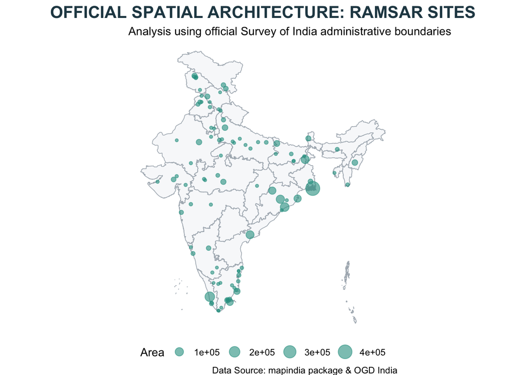

## The Acceleration of Conservation: A Temporal Growth Analysis

### How has the rate of RAMSAR designations in India changed over the last three decades, particularly since the 2020s?

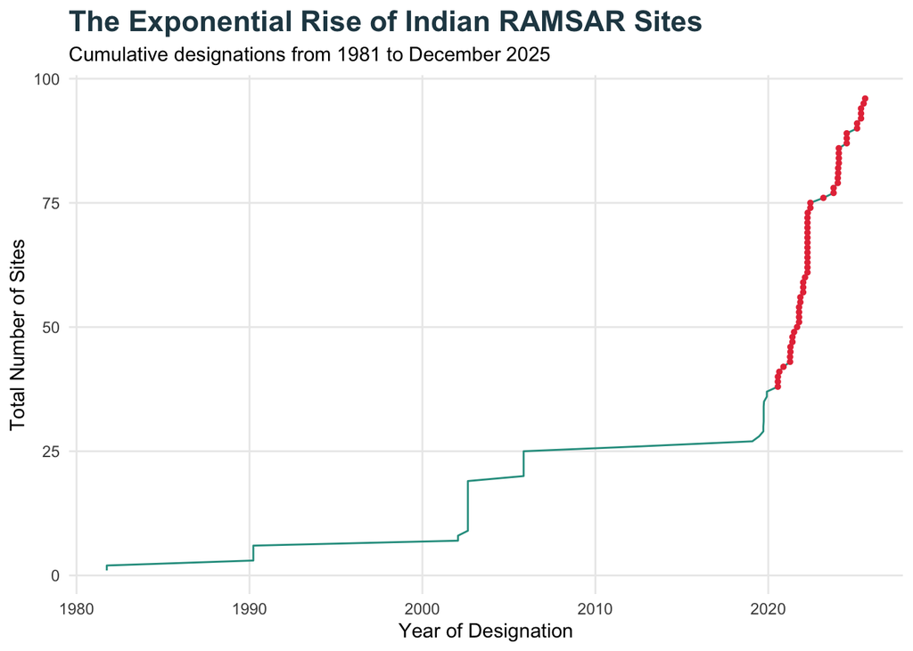

It is apparent from the above plot that a **Policy Inflection Point may have occurred around 2020**. While designations were sporadic from 1981 to 2010, the curve steepens sharply in the last five years with more than half (59) of India’s current Ramsar sites designated since 2020, signaling an aggressive shift in national environmental policy and a heightened commitment to international conservation standards.

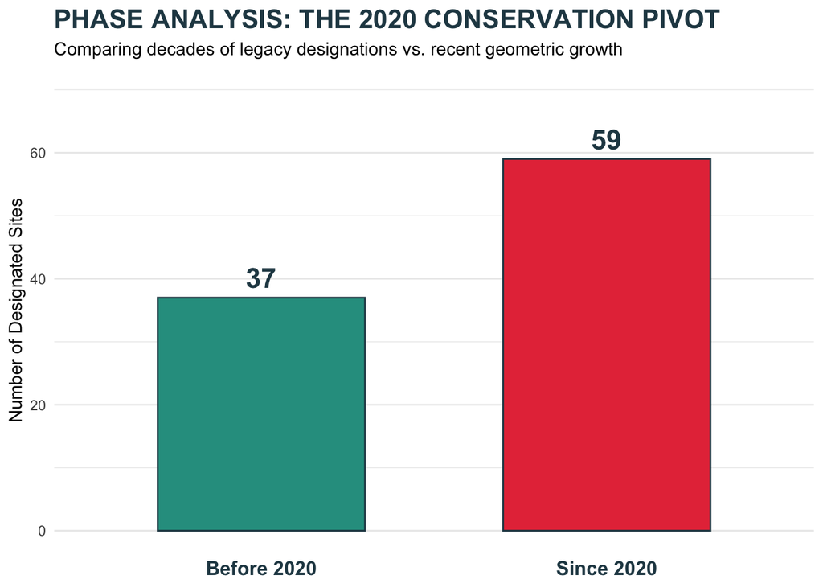

## State-wise Distribution: The Pareto of Wetlands

### Does a small number of states hold the majority of India’s RAMSAR designations, or is it evenly distributed?

Count sites by `StateName` and sort them in descending order.

Highlights regional leaders in ecological preservation.

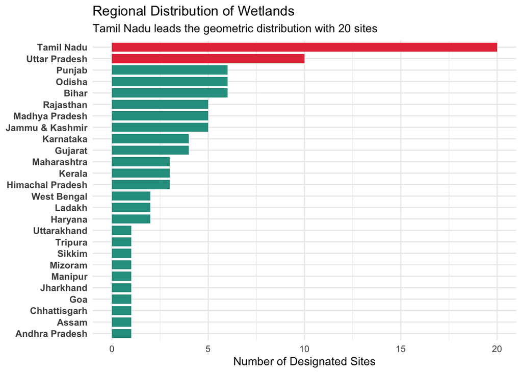

The bar plot confirms a disparity in wetland distribution. **Tamil Nadu** leads the country with **20 sites**, followed by Uttar Pradesh (**10**). These top two states have **31.2%** of the total number of RAMSAR sites in India. Further, the share of the top 5 states in this metric is an overwhelming —**50.0%**. Conversely, **50.0% of states (13)** have only 1or 2 sites, suggesting that conservation success is currently driven by specific state-level initiatives rather than a perfectly uniform national spread.

## The Size Spectrum: Are we protecting large basins or small habitats?

### What is the distribution of wetland sizes (Area), and are there “mega-wetlands” that skew the national average?

Transform the `Area` column to numeric and create a histogram or density plot.

Shows if India focuses on massive ecological systems or smaller, niche biodiversity hotspots.

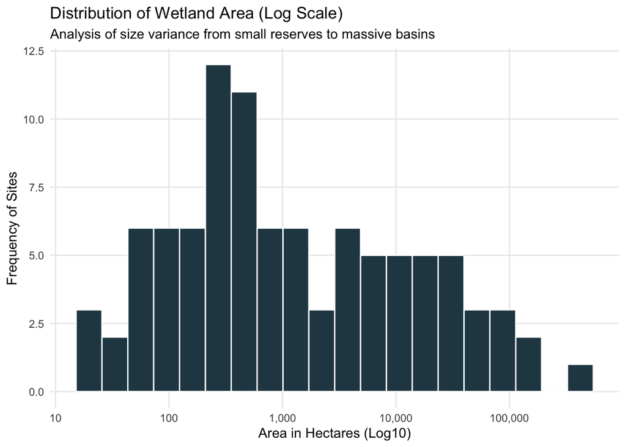

## Latitude & Area: The North-South Conservation Divide

### Is there a relationship between geographical latitude and the size of designated wetlands?

Helps visualize if northern (Himalayan) wetlands tend to be larger or smaller than southern/peninsular ones.

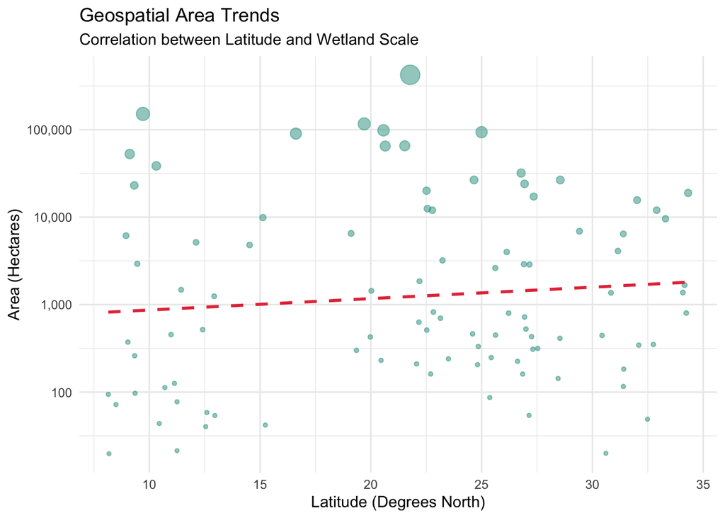

## District-Level Granularity within Leading States

### Within the states with the most RAMSAR sites, are the wetlands clustered in specific districts or spread across the state?

Identifies “ecological hubs” at a local government level, which is useful for management authority analysis.

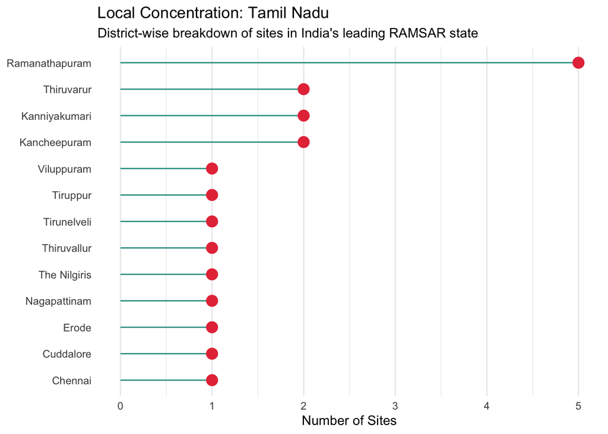

## The “Anthropogenic Shift”: Natural vs. Human-Made

This analysis reveals if India is increasingly relying on man-made reservoirs for international conservation status and determines if India’s conservation strategy is shifting toward protecting infrastructure-based biodiversity.

Recent additions like **Siliserh Lake** (Rajasthan) and **Kopra Reservoir** (Chhattisgarh) are artificial ecosystems.

### What percentage of India’s RAMSAR network is comprised of human-made “Artificial” wetlands, and how does their average size compare to natural basins?

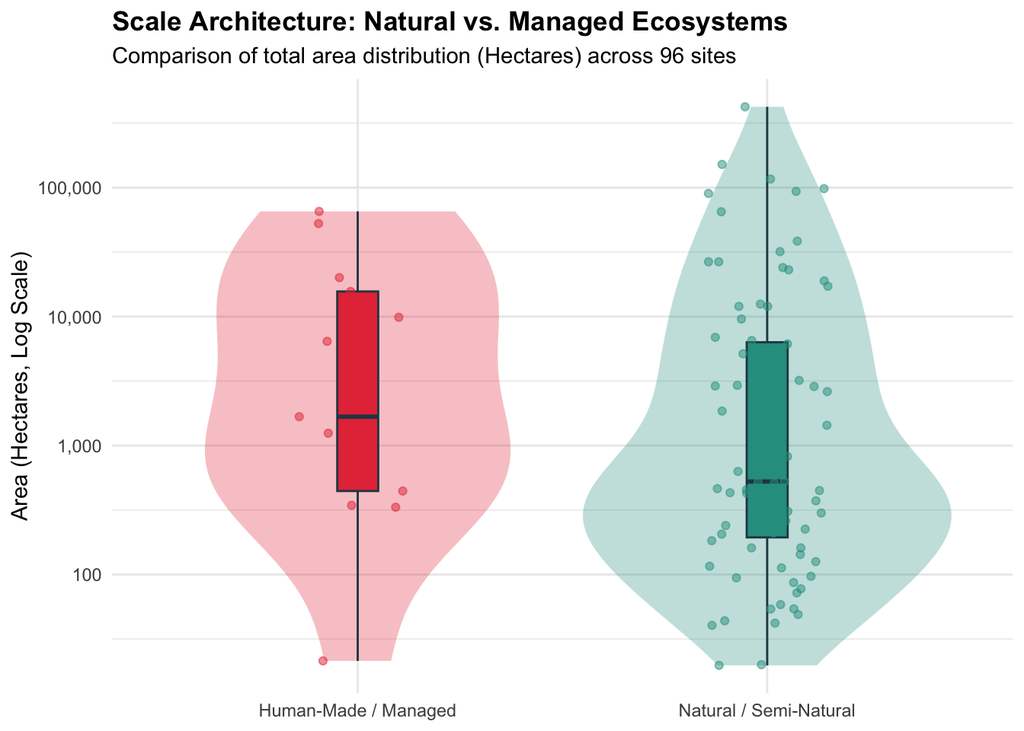

## Semantic Analysis of Uniqueness: The Biodiversity Fingerprint

A good approach to understand the uniqueness of India’s RAMSAR sites is by performing Natural Language Processing (NLP) on the qualitative data (categorical data) contained in our dataset. This can be done by extracting and identifying specific keywords from the observation “Uniqueness” of the dataset that justify why these 96 sites were recognized by awarding them with international status.

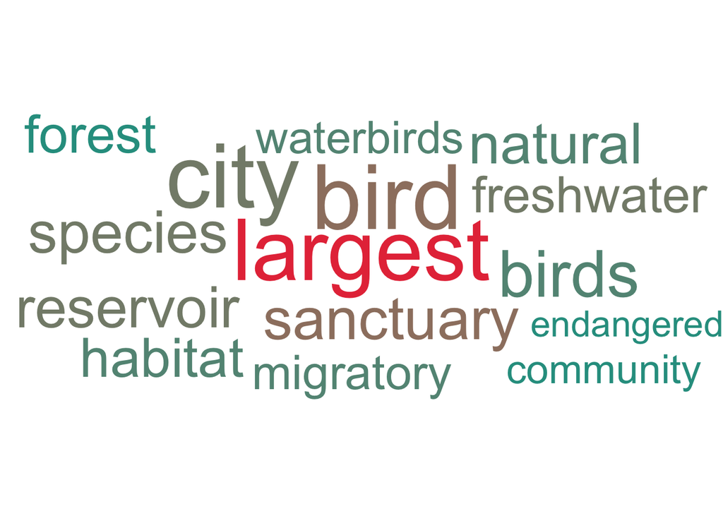

### What are the top three Ecological Drivers (e.g., Birds, Flood Control) that qualify an Indian site for RAMSAR status?

We extract the keywords of Uniqueness Observation to see what makes a wetland internationally significant in the Indian context.

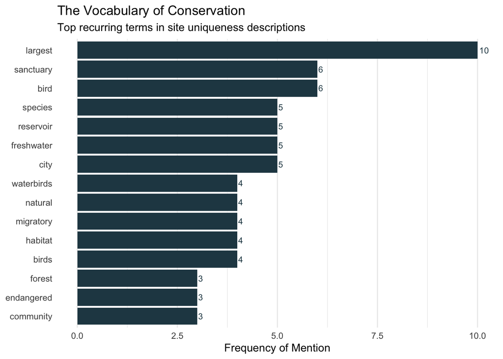

## The “Seasonality” of Global Recognition

### Is there a “policy window” where sites are more likely to be designated around specific international events (e.g., World Wetlands Day or Independence Day)?

Reveals if political timelines influence ecological milestones. A radial plot to see if designations cluster around specific months (Policy Momentum).

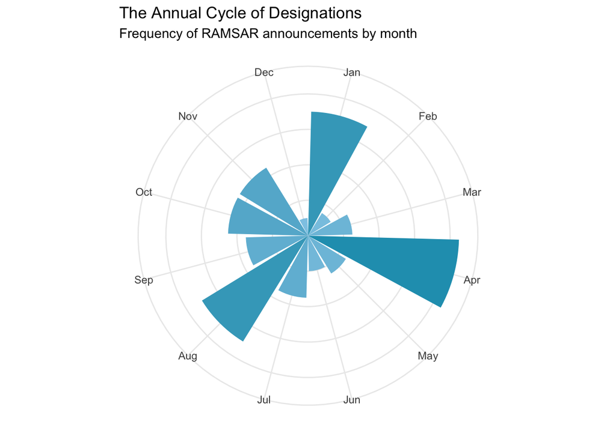

As can be inferred from the radial plot, the announcement of RAMSAR sites are not distributed evenly throughout the year. Rather, we can observe a nesting in a few months, like **Apr,** when **17** sites were declared, and in **Jan** when **14**, and in **Aug,** when again, **14** sites were declared as RAMSAR sites. This aligns with prominent annual events such as **World Wetlands Day on February** **2nd** or **Independence day on August 15th**. For instance, on India’s 75th Independence Day, Environment Minister Sri Bhupendra Yadav declared on social media pllatform ‘X’ that he was, “Elated to inform that 11 more Indian wetlands have got RAMSAR recognition. This takes our tally to 75 sites.” [1] This shows that there is a window of announcement, often tied to global environmental milestones and diplomatic postures.

## Fragmented vs. Clustered Landscapes

### Are Indian RAMSAR sites getting clustered or isolated?

Identify Hotspots (like the Tamil Nadu belt) versus Isolated sites (like Pala Wetland in Mizoram). This calculates how far each site is from its closest “Conservation Neighbor” to identify hubs.

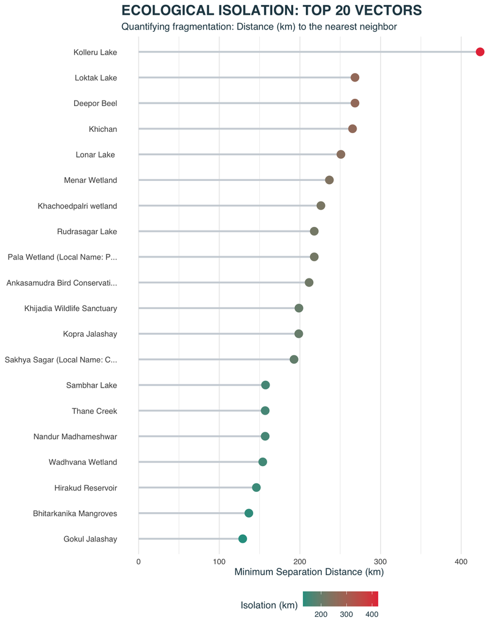

Sites like **Kolleru Lake (423 km** away from the nearest wetland), **Deepor Beel (268 km)**, and **Loktak Lake (268 km)** are what experts call **“Ecological Islands.”** These sites are geographically lonely considering the nearest RAMSAR site. Hence, from a policy perspective, this necessitates localized, high-intensity management because they cannot rely on neighboring wetlands. At the other end of the spectrum, we have sites like **Chitrangudi and Kanjirankulam (2.07 km)** or **Nagi and Nakti (5.34 km)**. These are not just individual sites; they are **Conservation Complexes**. Geometrically, these nodes are so close they likely share the same migratory bird populations and water tables. This suggests that recent policy (post-2020) has shifted toward protecting “clusters,” effectively creating larger “Safety Zones” rather than just isolated spots.

## Management Diversity & Scale

The dataset names various authorities, from “Retired Academics” to “Forest Departments.”

### Does the type of `ManagementAuthority` correlate with the **Total Area** protected? Do institutional authorities manage larger “Mega-Wetlands” while local/academic bodies manage smaller “Niche Sanctuaries”?

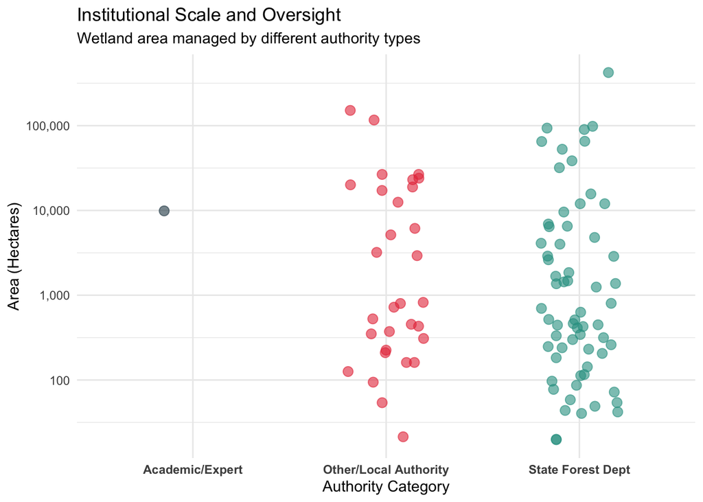